# Historic data

```r
library(tidyverse)
library(lubridate)

#new this week
library(rnoaa)
library(trend)
```

# We will use the “rnoaa” package to download data directly from the internet. Remember that you can type “?rnoaa” to get a help screen about the package.

```r
climate_data <- ghcnd_search(
  stationid = "USC00053005",
  date_min = "1988-01-01",
  date_max = "2020-12-31",
  var = c("SNOW", "TMAX", "TMIN", "PRCP", "TOBS", "SNWD")
)
```

# In this section we write a function to clean up the data. Remember that “select(-something)” will get rid of that column.

```r
variable_reducer <- function(df){
  min_data = dplyr::select(df, -id, -mflag, -qflag, -sflag)
}

relevant_data <- climate_data %>%
  map(., variable_reducer)

clim_dat <- reduce(relevant_data, full_join, by = c("date")) %>%
  arrange(date) %>%
  mutate_if(is.numeric, vars(./10))
```

# Let’s now make a plot.

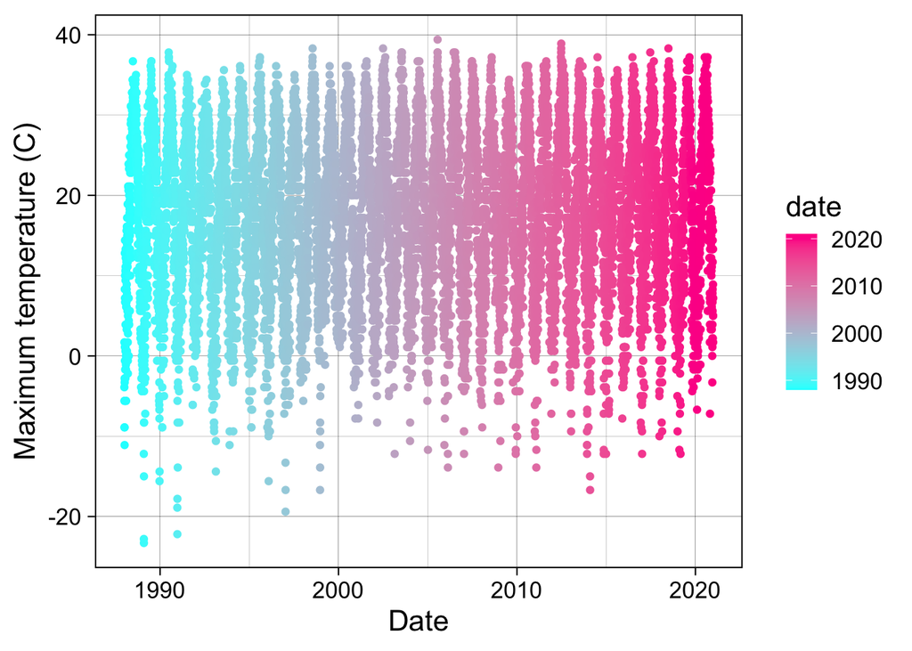

```r
ggplot(clim_dat, aes(x = date, y = tmax, color = date)) +
  geom_point() +
  ylab("Maximum temperature (C)") +
  xlab("Date") +
  theme_linedraw(base_size = 16) +
  scale_color_gradient(low = 'cyan', high = 'deeppink', trans = "date")
```

# Alternative to the one above we can use an “expression” in the ylab line if we want a superscript.

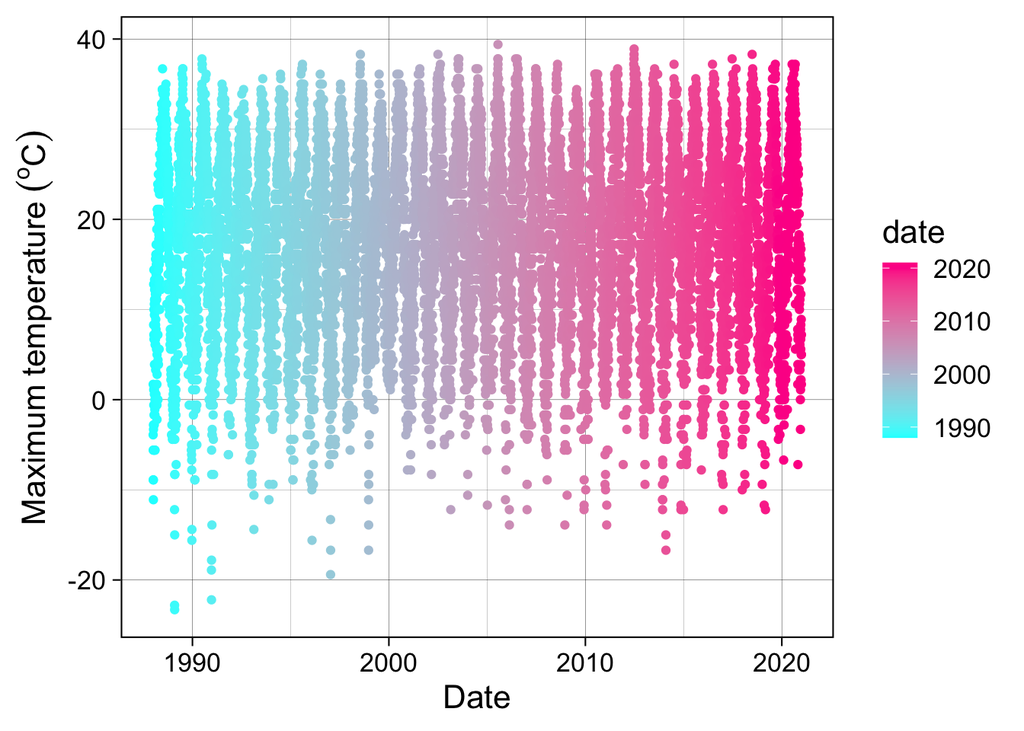

```r
ggplot(clim_dat, aes(x = date, y = tmax, color = date)) +
  geom_point() +
  ylab(expression(Maximum~temperature~(""^o*C))) +
  xlab("Date") +
  theme_linedraw(base_size = 16) +
  scale_color_gradient(low = 'cyan', high = 'deeppink', trans = "date")
```

# We can also add a trendline to the plot with stat_smooth. Check out “?stat_smooth” to get a help file.

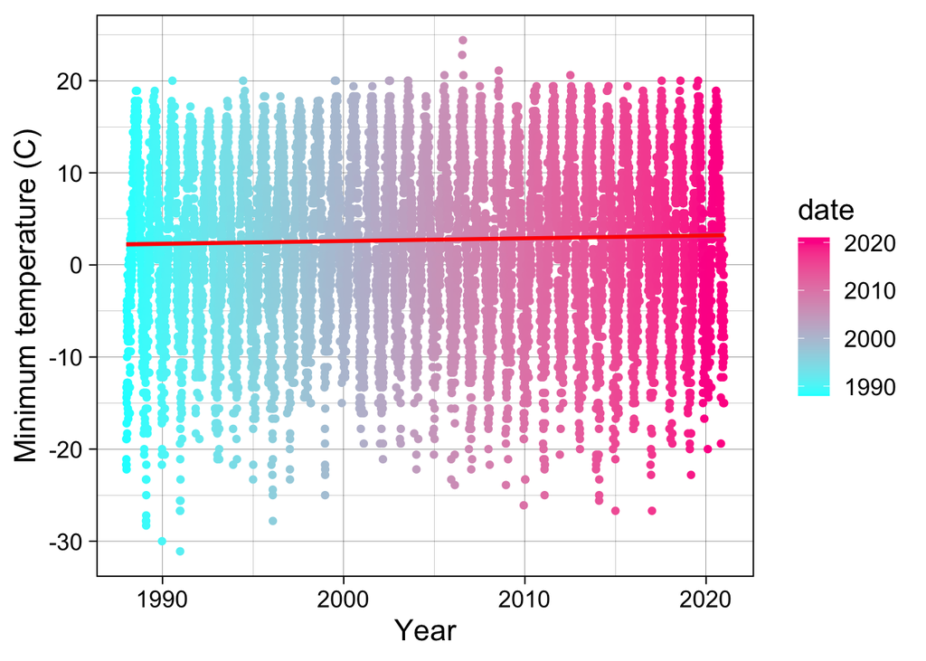

```r
ggplot(clim_dat, aes(x = date, y = tmin, color = date)) +
  geom_point() +
  xlab("Year") +
  ylab("Minimum temperature (C)") +
  theme_linedraw(base_size = 16) +
  scale_color_gradient(low = "cyan", high = "deeppink", trans = "date") +
  stat_smooth(method = "lm", color = "red")
```

# Now let’s use our mutate function from dplyr (in the tidyverse) and lubridate to make columns of month, year and day.

```r
myd_dat <- clim_dat %>%
  mutate(month = month(date),
         year = year(date),
         day = day(date))
```

# Making those columns allows us to filter by day, month, year. filter(month == 9) means only keep the months equal to 9. Filter (day %in% 16:20) means keep all days equal to 16-20. Summarize can be used to get some summary statistics on the data. When getting summary stats it is generally useful to include “na.rm = TRUE” this means remove any na values from the calculations.

```r
m_avg <- myd_dat %>%
  filter(month == 9) %>%
  group_by(month, year) %>%
  summarize(m_tmin = mean(tmin))


days_tmin <- myd_dat %>%
  filter(day %in% 16:20) %>%
  group_by(month, day) %>%
  summarize(max_tmin = max(tmin, na.rm = TRUE),
            min_tmin = min(tmin, na.rm = TRUE),
            avg_tmin = mean(tmin, na.rm = TRUE))
```

```r
monitor_days <- myd_dat %>%
  filter(day %in% 16:20) %>%
  filter(month == 8) %>%
  group_by(month, day) %>%
  summarize(max_tmin = max(tmin, na.rm = TRUE),
            min_tmin = min(tmin, na.rm = TRUE),
            avg_tmin = mean(tmin, na.rm = TRUE),
            avg_p = mean(prcp, na.rm = TRUE),
            max_p = max(prcp, na.rm = TRUE),
            )
```

# Last let’s run a non-parametric Mann-Kendall trend test on the data. In this test we want two things: 1. is the trend significant? (i.e., the p-value) and 2. what is the slope? (i.e., the Sen’s slope)

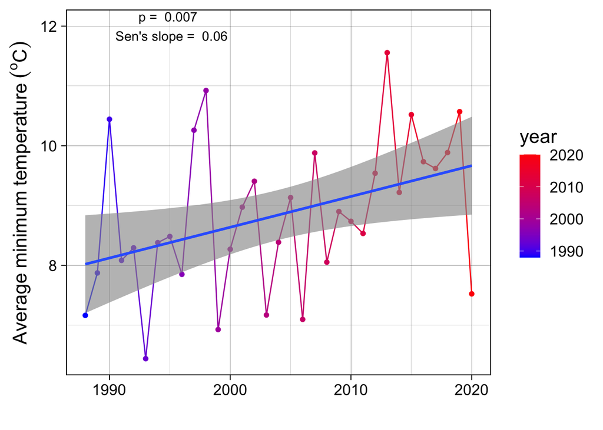

```r
t_min_test <- sens.slope(m_avg$m_tmin)


ggplot(m_avg, aes(x = year, y = m_tmin, color = year)) +
  geom_point() +
  geom_line() +
  xlab("") +
  ylab(expression(Average~minimum~temperature~(""^o*C))) +
  theme_linedraw(base_size = 16) +
  stat_smooth (method = lm) +
  stat_smooth (method = lm) +
  scale_color_gradient(low = "blue", high = "red") +
  annotate("text", x = 1995, y = 12, label = paste("p = ", round(t_min_test$p.value, digits = 3), "\n",
                                                      "Sen's slope = ", round(t_min_test$estimates, digits = 2)))
```